# Retail Sales Analytics: Business Intelligence Dashboard

## Business Scenario

A national retail company aims to improve profitability and operational performance by analyzing historical sales data. Management requires insights into sales trends, customer purchasing behavior, product performance, regional profitability, and the impact of discounts on profit.

The objective of this project is to transform raw transactional data into actionable business insights that support strategic decision-making.

## Business Objectives

- Analyze overall sales and profitability.
- Identify top-performing products and categories.
- Evaluate regional sales performance.
- Understand customer purchasing behavior.
- Measure the impact of discounts on profitability.
- Provide data-driven business recommendations.

```python
# Import required libraries

import pandas as pd
import numpy as np

import matplotlib.pyplot as plt
import seaborn as sns

from scipy import stats

# Display settings
pd.set_option("display.max_columns", None)

# Plot style
plt.style.use("default")
sns.set_theme(style="whitegrid")

# Ignore warnings
import warnings
warnings.filterwarnings("ignore")
```

```python
df = pd.read_csv("Sample - Superstore.csv", encoding="latin1")
df.head()
```

|  | Row ID | Order ID | Order Date | Ship Date | Ship Mode | Customer ID | Customer Name | Segment | Country | City | State | Postal Code | Region | Product ID | Category | Sub-Category | Product Name | Sales | Quantity | Discount | Profit |
| --- | --- | --- | --- | --- | --- | --- | --- | --- | --- | --- | --- | --- | --- | --- | --- | --- | --- | --- | --- | --- | --- |
| 0 | 1 | CA-2016-152156 | 11/8/2016 | 11/11/2016 | Second Class | CG-12520 | Claire Gute | Consumer | United States | Henderson | Kentucky | 42420 | South | FUR-BO-10001798 | Furniture | Bookcases | Bush Somerset Collection Bookcase | 261.9600 | 2 | 0.00 | 41.9136 |
| 1 | 2 | CA-2016-152156 | 11/8/2016 | 11/11/2016 | Second Class | CG-12520 | Claire Gute | Consumer | United States | Henderson | Kentucky | 42420 | South | FUR-CH-10000454 | Furniture | Chairs | Hon Deluxe Fabric Upholstered Stacking Chairs,... | 731.9400 | 3 | 0.00 | 219.5820 |
| 2 | 3 | CA-2016-138688 | 6/12/2016 | 6/16/2016 | Second Class | DV-13045 | Darrin Van Huff | Corporate | United States | Los Angeles | California | 90036 | West | OFF-LA-10000240 | Office Supplies | Labels | Self-Adhesive Address Labels for Typewriters b... | 14.6200 | 2 | 0.00 | 6.8714 |
| 3 | 4 | US-2015-108966 | 10/11/2015 | 10/18/2015 | Standard Class | SO-20335 | Sean O'Donnell | Consumer | United States | Fort Lauderdale | Florida | 33311 | South | FUR-TA-10000577 | Furniture | Tables | Bretford CR4500 Series Slim Rectangular Table | 957.5775 | 5 | 0.45 | -383.0310 |
| 4 | 5 | US-2015-108966 | 10/11/2015 | 10/18/2015 | Standard Class | SO-20335 | Sean O'Donnell | Consumer | United States | Fort Lauderdale | Florida | 33311 | South | OFF-ST-10000760 | Office Supplies | Storage | Eldon Fold 'N Roll Cart System | 22.3680 | 2 | 0.20 | 2.5164 |

## Data Inspection

Before performing any analysis, it is essential to understand the dataset's structure and assess its overall quality. This step examines the dimensions, data types, summary statistics, and identifies potential issues such as missing values and duplicate records.

```python
# Display first five rows
df.head()
```

|  | Row ID | Order ID | Order Date | Ship Date | Ship Mode | Customer ID | Customer Name | Segment | Country | City | State | Postal Code | Region | Product ID | Category | Sub-Category | Product Name | Sales | Quantity | Discount | Profit |
| --- | --- | --- | --- | --- | --- | --- | --- | --- | --- | --- | --- | --- | --- | --- | --- | --- | --- | --- | --- | --- | --- |
| 0 | 1 | CA-2016-152156 | 11/8/2016 | 11/11/2016 | Second Class | CG-12520 | Claire Gute | Consumer | United States | Henderson | Kentucky | 42420 | South | FUR-BO-10001798 | Furniture | Bookcases | Bush Somerset Collection Bookcase | 261.9600 | 2 | 0.00 | 41.9136 |
| 1 | 2 | CA-2016-152156 | 11/8/2016 | 11/11/2016 | Second Class | CG-12520 | Claire Gute | Consumer | United States | Henderson | Kentucky | 42420 | South | FUR-CH-10000454 | Furniture | Chairs | Hon Deluxe Fabric Upholstered Stacking Chairs,... | 731.9400 | 3 | 0.00 | 219.5820 |
| 2 | 3 | CA-2016-138688 | 6/12/2016 | 6/16/2016 | Second Class | DV-13045 | Darrin Van Huff | Corporate | United States | Los Angeles | California | 90036 | West | OFF-LA-10000240 | Office Supplies | Labels | Self-Adhesive Address Labels for Typewriters b... | 14.6200 | 2 | 0.00 | 6.8714 |
| 3 | 4 | US-2015-108966 | 10/11/2015 | 10/18/2015 | Standard Class | SO-20335 | Sean O'Donnell | Consumer | United States | Fort Lauderdale | Florida | 33311 | South | FUR-TA-10000577 | Furniture | Tables | Bretford CR4500 Series Slim Rectangular Table | 957.5775 | 5 | 0.45 | -383.0310 |
| 4 | 5 | US-2015-108966 | 10/11/2015 | 10/18/2015 | Standard Class | SO-20335 | Sean O'Donnell | Consumer | United States | Fort Lauderdale | Florida | 33311 | South | OFF-ST-10000760 | Office Supplies | Storage | Eldon Fold 'N Roll Cart System | 22.3680 | 2 | 0.20 | 2.5164 |

```python
# Display last five rows
df.tail()
```

|  | Row ID | Order ID | Order Date | Ship Date | Ship Mode | Customer ID | Customer Name | Segment | Country | City | State | Postal Code | Region | Product ID | Category | Sub-Category | Product Name | Sales | Quantity | Discount | Profit |
| --- | --- | --- | --- | --- | --- | --- | --- | --- | --- | --- | --- | --- | --- | --- | --- | --- | --- | --- | --- | --- | --- |
| 9989 | 9990 | CA-2014-110422 | 1/21/2014 | 1/23/2014 | Second Class | TB-21400 | Tom Boeckenhauer | Consumer | United States | Miami | Florida | 33180 | South | FUR-FU-10001889 | Furniture | Furnishings | Ultra Door Pull Handle | 25.248 | 3 | 0.2 | 4.1028 |
| 9990 | 9991 | CA-2017-121258 | 2/26/2017 | 3/3/2017 | Standard Class | DB-13060 | Dave Brooks | Consumer | United States | Costa Mesa | California | 92627 | West | FUR-FU-10000747 | Furniture | Furnishings | Tenex B1-RE Series Chair Mats for Low Pile Car... | 91.960 | 2 | 0.0 | 15.6332 |
| 9991 | 9992 | CA-2017-121258 | 2/26/2017 | 3/3/2017 | Standard Class | DB-13060 | Dave Brooks | Consumer | United States | Costa Mesa | California | 92627 | West | TEC-PH-10003645 | Technology | Phones | Aastra 57i VoIP phone | 258.576 | 2 | 0.2 | 19.3932 |
| 9992 | 9993 | CA-2017-121258 | 2/26/2017 | 3/3/2017 | Standard Class | DB-13060 | Dave Brooks | Consumer | United States | Costa Mesa | California | 92627 | West | OFF-PA-10004041 | Office Supplies | Paper | It's Hot Message Books with Stickers, 2 3/4" x 5" | 29.600 | 4 | 0.0 | 13.3200 |
| 9993 | 9994 | CA-2017-119914 | 5/4/2017 | 5/9/2017 | Second Class | CC-12220 | Chris Cortes | Consumer | United States | Westminster | California | 92683 | West | OFF-AP-10002684 | Office Supplies | Appliances | Acco 7-Outlet Masterpiece Power Center, Wihtou... | 243.160 | 2 | 0.0 | 72.9480 |

```python
# Dataset dimensions
print(f"Rows: {df.shape[0]}")
print(f"Columns: {df.shape[1]}")
```

```
Rows: 9994
Columns: 21
```

```python
# Column names
df.columns
```

```
Index(['Row ID', 'Order ID', 'Order Date', 'Ship Date', 'Ship Mode',
       'Customer ID', 'Customer Name', 'Segment', 'Country', 'City', 'State',
       'Postal Code', 'Region', 'Product ID', 'Category', 'Sub-Category',
       'Product Name', 'Sales', 'Quantity', 'Discount', 'Profit'],
      dtype='object')
```

```python
# Data types
df.info()
```

[output not shown]

```python
# Summary statistics
df.describe().T
```

|  | count | mean | std | min | 25% | 50% | 75% | max |
| --- | --- | --- | --- | --- | --- | --- | --- | --- |
| Row ID | 9994.0 | 4997.500000 | 2885.163629 | 1.000 | 2499.25000 | 4997.5000 | 7495.750 | 9994.000 |
| Postal Code | 9994.0 | 55190.379428 | 32063.693350 | 1040.000 | 23223.00000 | 56430.5000 | 90008.000 | 99301.000 |
| Sales | 9994.0 | 229.858001 | 623.245101 | 0.444 | 17.28000 | 54.4900 | 209.940 | 22638.480 |
| Quantity | 9994.0 | 3.789574 | 2.225110 | 1.000 | 2.00000 | 3.0000 | 5.000 | 14.000 |
| Discount | 9994.0 | 0.156203 | 0.206452 | 0.000 | 0.00000 | 0.2000 | 0.200 | 0.800 |
| Profit | 9994.0 | 28.656896 | 234.260108 | -6599.978 | 1.72875 | 8.6665 | 29.364 | 8399.976 |

```python
# Check missing values
df.isnull().sum()
```

```
Row ID           0
Order ID         0
Order Date       0
Ship Date        0
Ship Mode        0
Customer ID      0
Customer Name    0
Segment          0
Country          0
City             0
State            0
Postal Code      0
Region           0
Product ID       0
Category         0
Sub-Category     0
Product Name     0
Sales            0
Quantity         0
Discount         0
Profit           0
dtype: int64
```

```python
# Check duplicate rows
print("Duplicate rows:", df.duplicated().sum())
```

```
Duplicate rows: 0
```

### Initial Observations

- The dataset contains transactional retail sales data.
- Each row represents an individual customer order.
- The dataset includes customer, product, geographic, shipping, and financial information.
- Missing values and duplicate records will be addressed during the data cleaning phase.

## Data Cleaning

Data cleaning ensures the dataset is accurate, consistent, and suitable for analysis. The following checks are performed:

- Missing values
- Duplicate records
- Data type corrections
- Date formatting
- Consistency checks

```python
# Convert date columns
df["Order Date"] = pd.to_datetime(df["Order Date"])
df["Ship Date"] = pd.to_datetime(df["Ship Date"])
```

```python
missing = df.isnull().sum()

missing[missing > 0]
```

```
Series([], dtype: int64)
```

```python
print("Duplicate rows before:", df.duplicated().sum())

df = df.drop_duplicates()

print("Duplicate rows after:", df.duplicated().sum())
```

```
Duplicate rows before: 0
Duplicate rows after: 0
```

```python
df["Order Date"] = pd.to_datetime(
    df["Order Date"],
    format="%m/%d/%Y"
)

df["Ship Date"] = pd.to_datetime(
    df["Ship Date"],
    format="%m/%d/%Y"
)
print(df["Order Date"].min())
print(df["Order Date"].max())
```

```
2014-01-03 00:00:00
2017-12-30 00:00:00
```

```python
df["Order Date"] = pd.to_datetime(df["Order Date"].astype(str))
df["Ship Date"] = pd.to_datetime(df["Ship Date"].astype(str))

df["Year"] = df["Order Date"].dt.year
df["Month"] = df["Order Date"].dt.month_name()
df["Quarter"] = df["Order Date"].dt.quarter
df["Day"] = df["Order Date"].dt.day_name()
```

```python
df.head()
```

|  | Row ID | Order ID | Order Date | Ship Date | Ship Mode | Customer ID | Customer Name | Segment | Country | City | State | Postal Code | Region | Product ID | Category | Sub-Category | Product Name | Sales | Quantity | Discount | Profit | Year | Month | Quarter | Day |
| --- | --- | --- | --- | --- | --- | --- | --- | --- | --- | --- | --- | --- | --- | --- | --- | --- | --- | --- | --- | --- | --- | --- | --- | --- | --- |
| 0 | 1 | CA-2016-152156 | 2016-11-08 | 2016-11-11 | Second Class | CG-12520 | Claire Gute | Consumer | United States | Henderson | Kentucky | 42420 | South | FUR-BO-10001798 | Furniture | Bookcases | Bush Somerset Collection Bookcase | 261.9600 | 2 | 0.00 | 41.9136 | 2016 | November | 4 | Tuesday |
| 1 | 2 | CA-2016-152156 | 2016-11-08 | 2016-11-11 | Second Class | CG-12520 | Claire Gute | Consumer | United States | Henderson | Kentucky | 42420 | South | FUR-CH-10000454 | Furniture | Chairs | Hon Deluxe Fabric Upholstered Stacking Chairs,... | 731.9400 | 3 | 0.00 | 219.5820 | 2016 | November | 4 | Tuesday |
| 2 | 3 | CA-2016-138688 | 2016-06-12 | 2016-06-16 | Second Class | DV-13045 | Darrin Van Huff | Corporate | United States | Los Angeles | California | 90036 | West | OFF-LA-10000240 | Office Supplies | Labels | Self-Adhesive Address Labels for Typewriters b... | 14.6200 | 2 | 0.00 | 6.8714 | 2016 | June | 2 | Sunday |
| 3 | 4 | US-2015-108966 | 2015-10-11 | 2015-10-18 | Standard Class | SO-20335 | Sean O'Donnell | Consumer | United States | Fort Lauderdale | Florida | 33311 | South | FUR-TA-10000577 | Furniture | Tables | Bretford CR4500 Series Slim Rectangular Table | 957.5775 | 5 | 0.45 | -383.0310 | 2015 | October | 4 | Sunday |
| 4 | 5 | US-2015-108966 | 2015-10-11 | 2015-10-18 | Standard Class | SO-20335 | Sean O'Donnell | Consumer | United States | Fort Lauderdale | Florida | 33311 | South | OFF-ST-10000760 | Office Supplies | Storage | Eldon Fold 'N Roll Cart System | 22.3680 | 2 | 0.20 | 2.5164 | 2015 | October | 4 | Sunday |

# Exploratory Data Analysis (EDA)

Exploratory Data Analysis (EDA) examines the underlying patterns, distributions, and relationships within the retail sales dataset. The objective is to gain a comprehensive understanding of business performance, customer behavior, product performance, and regional trends before conducting detailed business analysis.

Each analysis focuses on a specific business objective and concludes with key insights that support data-driven decision-making.

## Executive KPI Summary

### Objective

Provide a high-level overview of the company's overall business performance using key performance indicators (KPIs).

```python
total_sales = df["Sales"].sum()
total_profit = df["Profit"].sum()
total_orders = df["Order ID"].nunique()
total_customers = df["Customer ID"].nunique()
avg_order_value = total_sales / total_orders
profit_margin = (total_profit / total_sales) * 100

print(f"Total Sales: ${total_sales:,.2f}")
print(f"Total Profit: ${total_profit:,.2f}")
print(f"Total Orders: {total_orders}")
print(f"Total Customers: {total_customers}")
print(f"Average Order Value: ${avg_order_value:,.2f}")
print(f"Profit Margin: {profit_margin:.2f}%")
```

```
Total Sales: $2,297,200.86
Total Profit: $286,397.02
Total Orders: 5009
Total Customers: 793
Average Order Value: $458.61
Profit Margin: 12.47%
```

### Key Insight

The company generated **$2.30 million** in total sales and **$286.40 thousand** in profit from **5,009** unique orders placed by **793** customers. The average order value and positive profit margin indicate healthy overall business performance, providing a strong foundation for further analysis of sales trends, customer behavior, and profitability drivers.

## Sales Distribution

### Objective

Examine the distribution of sales across individual transactions to understand customer purchasing patterns and identify the presence of high-value orders.

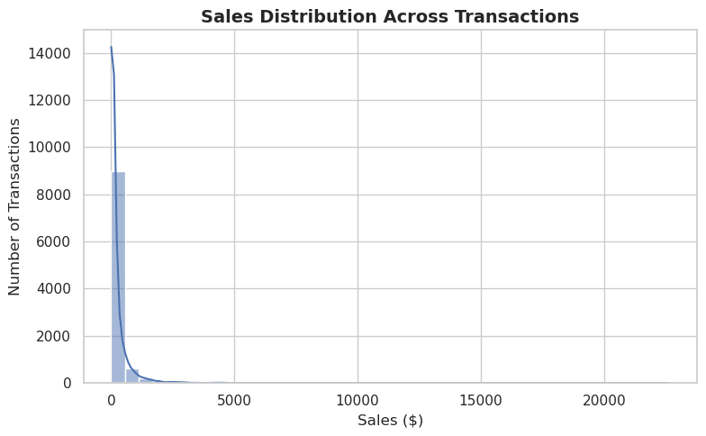

```python
plt.figure(figsize=(8,5))

sns.histplot(
    data=df,
    x="Sales",
    bins=40,
    kde=True
)

plt.title(
    "Sales Distribution Across Transactions",
    fontsize=14,
    fontweight="bold"
)

plt.xlabel("Sales ($)")
plt.ylabel("Number of Transactions")

plt.tight_layout()
plt.show()
```

### Key Insight

The sales distribution is positively skewed, indicating that most customer transactions involve relatively low purchase amounts, while a small number of high-value orders contribute disproportionately to total revenue. This pattern is common in retail businesses and suggests that premium purchases play an important role in overall sales performance.

## Profit Distribution

### Objective

Analyze the distribution of profit across transactions to identify profitable and loss-making sales.

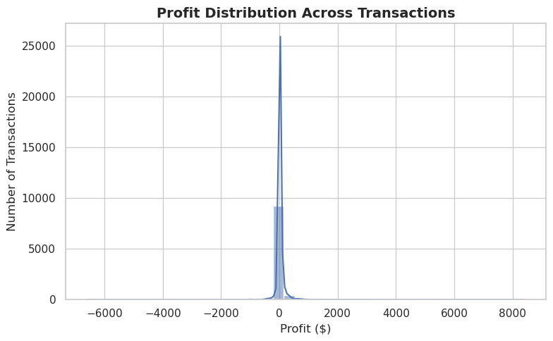

```python
plt.figure(figsize=(8,5))

sns.histplot(
    data=df,
    x="Profit",
    bins=40,
    kde=True
)

plt.title(
    "Profit Distribution Across Transactions",
    fontsize=14,
    fontweight="bold"
)

plt.xlabel("Profit ($)")
plt.ylabel("Number of Transactions")

plt.tight_layout()
plt.show()
```

### Key Insight

Profit values vary considerably across transactions, with the presence of both profitable and loss-making orders. The negative profit values indicate that certain products or heavily discounted transactions reduce overall profitability, highlighting opportunities to optimize pricing and discount strategies.

## Sales by Product Category

### Objective

Identify which product categories contribute the most to overall sales revenue.

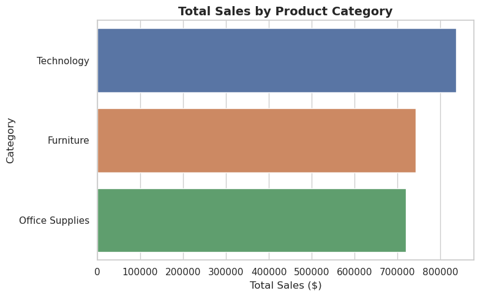

```
Category
Technology         836154.0330
Furniture          741999.7953
Office Supplies    719047.0320
Name: Sales, dtype: float64
```

```python
category_sales = (
    df.groupby("Category")["Sales"]
      .sum()
      .sort_values(ascending=False)
)

plt.figure(figsize=(8,5))

sns.barplot(
    x=category_sales.values,
    y=category_sales.index
)

plt.title(
    "Total Sales by Product Category",
    fontsize=14,
    fontweight="bold"
)

plt.xlabel("Total Sales ($)")
plt.ylabel("Category")

plt.tight_layout()

# Save for GitHub README
plt.savefig(
    "images/category_sales.png",
    dpi=300,
    bbox_inches="tight"
)

plt.show()

category_sales
```

### Key Insight

Technology generated the highest total sales (**$836,154**), followed by Furniture (**$742,000**) and Office Supplies (**$719,047**). This indicates that Technology is the company's primary revenue driver and should remain a strategic focus for inventory planning and marketing investment. However, sales performance should also be evaluated alongside profitability to ensure sustainable growth.

## Sales by Region

### Objective

Compare sales performance across different regions to identify the company's strongest and weakest markets.

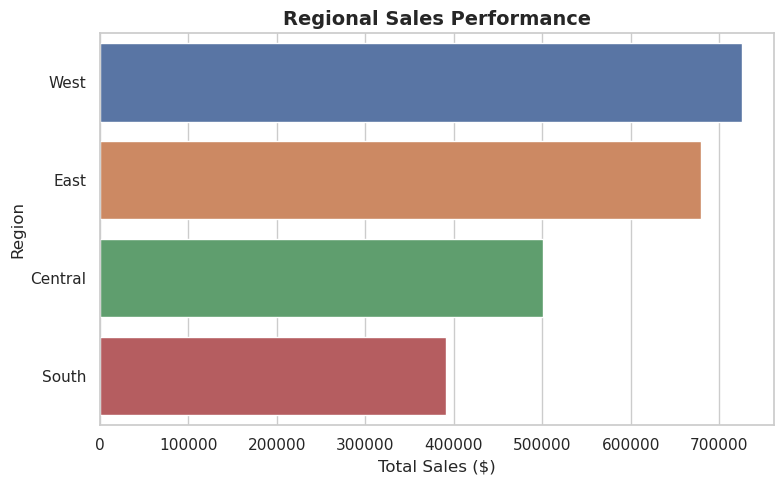

```
Region
West       725457.8245
East       678781.2400
Central    501239.8908
South      391721.9050
Name: Sales, dtype: float64
```

```python
region_sales = (
    df.groupby("Region")["Sales"]
      .sum()
      .sort_values(ascending=False)
)

plt.figure(figsize=(8,5))

sns.barplot(
    data=region_sales.reset_index(),
    x="Sales",
    y="Region"
)

plt.title(
    "Regional Sales Performance",
    fontsize=14,
    fontweight="bold"
)

plt.xlabel("Total Sales ($)")
plt.ylabel("Region")

plt.tight_layout()

plt.savefig(
    "images/regional_sales.png",
    dpi=300,
    bbox_inches="tight"
)

plt.show()

region_sales
```

### Key Insight

The West region recorded the highest sales (**$725,458**), followed by the East region (**$678,781**). In contrast, the South generated the lowest sales (**$391,722**), suggesting potential opportunities to strengthen marketing initiatives and improve market penetration in lower-performing regions.

## Sales by Customer Segment

### Objective

Evaluate the contribution of each customer segment to overall sales revenue.

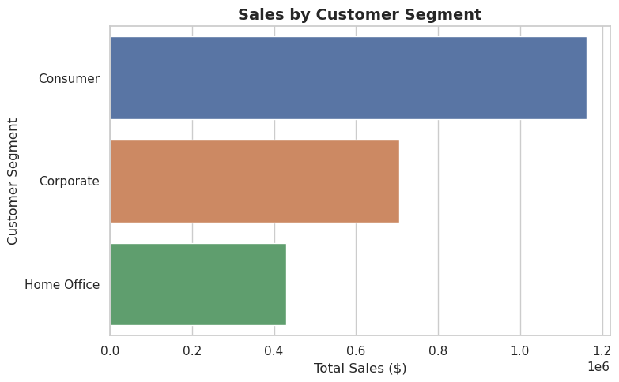

```
Segment
Consumer       1.161401e+06
Corporate      7.061464e+05
Home Office    4.296531e+05
Name: Sales, dtype: float64
```

```python
segment_sales = (
    df.groupby("Segment")["Sales"]
      .sum()
      .sort_values(ascending=False)
)

plt.figure(figsize=(8,5))

sns.barplot(
    data=segment_sales.reset_index(),
    x="Sales",
    y="Segment"
)

plt.title(
    "Sales by Customer Segment",
    fontsize=14,
    fontweight="bold"
)

plt.xlabel("Total Sales ($)")
plt.ylabel("Customer Segment")

plt.tight_layout()

plt.show()

segment_sales
```

### Key Insight

The Consumer segment contributed the largest share of sales (**$1.16 million**), significantly outperforming the Corporate and Home Office segments. This suggests that individual consumers represent the company's primary customer base and should remain a key focus for customer engagement and retention strategies.

## Shipping Mode Analysis

### Objective

Understand the distribution of sales across different shipping methods.

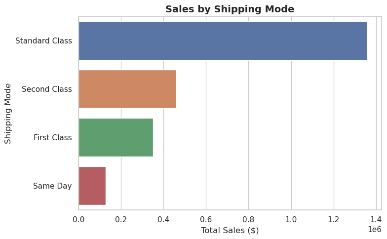

```
Ship Mode
Standard Class    1.358216e+06
Second Class      4.591936e+05
First Class       3.514284e+05
Same Day          1.283631e+05
Name: Sales, dtype: float64
```

```python
ship_sales = (
    df.groupby("Ship Mode")["Sales"]
      .sum()
      .sort_values(ascending=False)
)

plt.figure(figsize=(8,5))

sns.barplot(
    data=ship_sales.reset_index(),
    x="Sales",
    y="Ship Mode"
)

plt.title(
    "Sales by Shipping Mode",
    fontsize=14,
    fontweight="bold"
)

plt.xlabel("Total Sales ($)")
plt.ylabel("Shipping Mode")

plt.tight_layout()

plt.show()

ship_sales
```

### Key Insight

Standard Class accounted for the highest sales (**$1.36 million**), making it the preferred shipping method among customers. This suggests that most customers prioritize cost-effective delivery over faster shipping options, emphasizing the importance of maintaining efficient standard shipping operations.

## Correlation Analysis

### Objective

Examine the relationships between numerical variables to identify potential patterns and dependencies within the dataset.

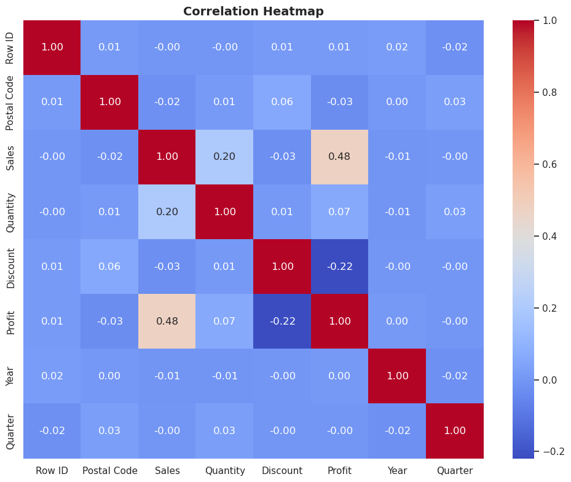

```python
numeric_df = df.select_dtypes(include=["number"])

plt.figure(figsize=(10,8))

sns.heatmap(
    numeric_df.corr(),
    annot=True,
    cmap="coolwarm",
    fmt=".2f"
)

plt.title(
    "Correlation Heatmap",
    fontsize=14,
    fontweight="bold"
)

plt.tight_layout()

plt.savefig(
    "images/correlation_heatmap.png",
    dpi=300,
    bbox_inches="tight"
)

plt.show()
```

### Key Insight

The correlation analysis indicates that most numerical variables exhibit weak to moderate relationships, suggesting that business performance is influenced by multiple factors rather than a single dominant variable. These insights provide a useful foundation for identifying variables that may support further predictive modeling and business analysis.

# Business Analytics

This section transforms exploratory findings into business-focused insights by addressing key management questions related to sales performance, product performance, customer behavior, regional trends, and profitability. The objective is to support strategic decision-making through data-driven analysis and actionable recommendations.

## Monthly Sales Trend

### Objective

Analyze monthly sales performance to identify seasonal trends, growth patterns, and periods of high or low business activity.

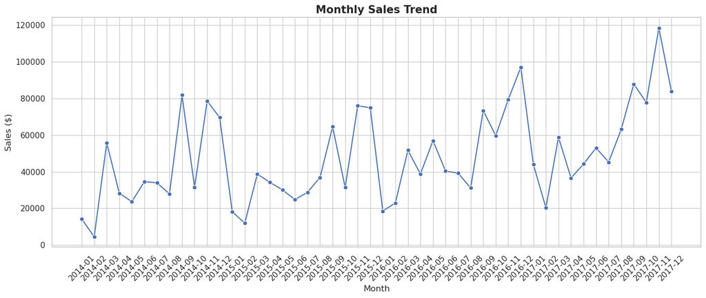

|  | Year_Month | Sales |
| --- | --- | --- |
| 0 | 2014-01 | 14236.895 |
| 1 | 2014-02 | 4519.892 |
| 2 | 2014-03 | 55691.009 |
| 3 | 2014-04 | 28295.345 |
| 4 | 2014-05 | 23648.287 |

```python
# Create Year-Month column
df["Year_Month"] = df["Order Date"].dt.to_period("M").astype(str)

# Monthly sales
monthly_sales = (
    df.groupby("Year_Month")["Sales"]
      .sum()
      .reset_index()
)

plt.figure(figsize=(14,6))

sns.lineplot(
    data=monthly_sales,
    x="Year_Month",
    y="Sales",
    marker="o"
)

plt.title(
    "Monthly Sales Trend",
    fontsize=15,
    fontweight="bold"
)

plt.xlabel("Month")
plt.ylabel("Sales ($)")

plt.xticks(rotation=45)

plt.tight_layout()

plt.savefig(
    "images/monthly_sales_trend.png",
    dpi=300,
    bbox_inches="tight"
)

plt.show()

monthly_sales.head()
```

### Key Insight

Monthly sales fluctuated throughout the analysis period, indicating the presence of seasonal demand patterns and changing customer purchasing behavior. Periods of strong sales may reflect promotional campaigns or seasonal demand, while lower-performing months highlight opportunities for targeted marketing initiatives.

## Yearly Sales Trend

### Objective

Evaluate annual sales performance to understand long-term business growth.

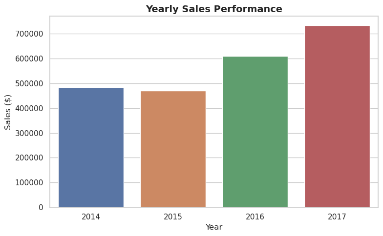

|  | Year | Sales |
| --- | --- | --- |
| 0 | 2014 | 484247.4981 |
| 1 | 2015 | 470532.5090 |
| 2 | 2016 | 609205.5980 |
| 3 | 2017 | 733215.2552 |

```python
yearly_sales = (
    df.groupby("Year")["Sales"]
      .sum()
      .reset_index()
)

plt.figure(figsize=(8,5))

sns.barplot(
    data=yearly_sales,
    x="Year",
    y="Sales"
)

plt.title(
    "Yearly Sales Performance",
    fontsize=14,
    fontweight="bold"
)

plt.xlabel("Year")
plt.ylabel("Sales ($)")

plt.tight_layout()

plt.show()

yearly_sales
```

## Top 10 Products by Sales

### Objective

Identify the products generating the highest sales revenue to support inventory planning, marketing investment, and product strategy.

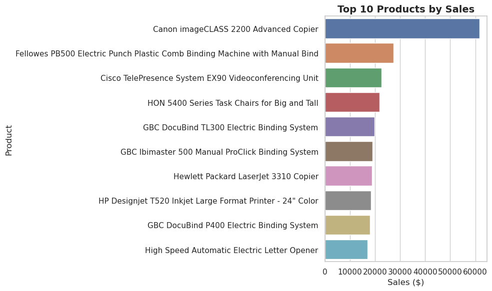

```
Product Name
Canon imageCLASS 2200 Advanced Copier                                          61599.824
Fellowes PB500 Electric Punch Plastic Comb Binding Machine with Manual Bind    27453.384
Cisco TelePresence System EX90 Videoconferencing Unit                          22638.480
HON 5400 Series Task Chairs for Big and Tall                                   21870.576
GBC DocuBind TL300 Electric Binding System                                     19823.479
GBC Ibimaster 500 Manual ProClick Binding System                               19024.500
Hewlett Packard LaserJet 3310 Copier                                           18839.686
HP Designjet T520 Inkjet Large Format Printer - 24" Color                      18374.895
GBC DocuBind P400 Electric Binding System                                      17965.068
High Speed Automatic Electric Letter Opener                                    17030.312
Name: Sales, dtype: float64
```

```python
top_products = (
    df.groupby("Product Name")["Sales"]
      .sum()
      .sort_values(ascending=False)
      .head(10)
)

plt.figure(figsize=(10,6))

sns.barplot(
    x=top_products.values,
    y=top_products.index
)

plt.title(
    "Top 10 Products by Sales",
    fontsize=14,
    fontweight="bold"
)

plt.xlabel("Sales ($)")
plt.ylabel("Product")

plt.tight_layout()

plt.savefig(
    "images/top_products.png",
    dpi=300,
    bbox_inches="tight"
)

plt.show()

top_products
```

### Key Insight

The Canon imageCLASS 2200 Advanced Copier generated the highest sales among all products, followed by several premium office equipment items. These high-performing products contribute substantially to overall revenue and should remain priorities for inventory management, supplier relationships, and promotional campaigns.

## Bottom 10 Products by Profit

### Objective

Identify the products generating the lowest profit to uncover items that may require pricing, discount, or inventory strategy adjustments.

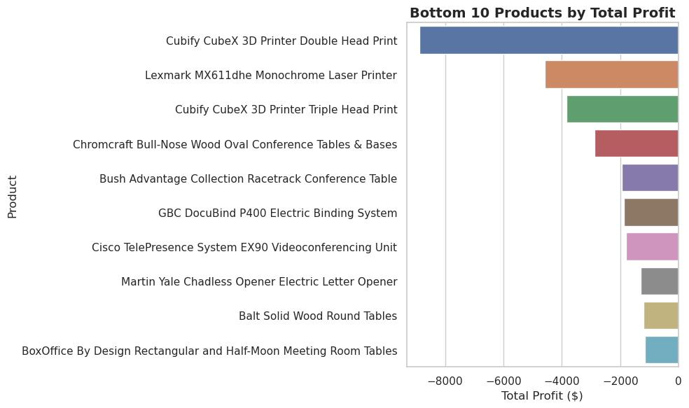

```
Product Name
Cubify CubeX 3D Printer Double Head Print                           -8879.9704
Lexmark MX611dhe Monochrome Laser Printer                           -4589.9730
Cubify CubeX 3D Printer Triple Head Print                           -3839.9904
Chromcraft Bull-Nose Wood Oval Conference Tables & Bases            -2876.1156
Bush Advantage Collection Racetrack Conference Table                -1934.3976
GBC DocuBind P400 Electric Binding System                           -1878.1662
Cisco TelePresence System EX90 Videoconferencing Unit               -1811.0784
Martin Yale Chadless Opener Electric Letter Opener                  -1299.1836
Balt Solid Wood Round Tables                                        -1201.0581
BoxOffice By Design Rectangular and Half-Moon Meeting Room Tables   -1148.4375
Name: Profit, dtype: float64
```

```python
bottom_profit = (
    df.groupby("Product Name")["Profit"]
      .sum()
      .sort_values()
      .head(10)
)

plt.figure(figsize=(10,6))

sns.barplot(
    data=bottom_profit.reset_index(),
    x="Profit",
    y="Product Name"
)

plt.title(
    "Bottom 10 Products by Total Profit",
    fontsize=14,
    fontweight="bold"
)

plt.xlabel("Total Profit ($)")
plt.ylabel("Product")

plt.tight_layout()

plt.savefig(
    "images/bottom_profit_products.png",
    dpi=300,
    bbox_inches="tight"
)

plt.show()

bottom_profit
```

### Key Insight

Several products generated substantial financial losses, with the Cubify CubeX 3D Printer Double Head Print recording the lowest overall profit. These products should be reviewed to determine whether pricing strategies, supplier costs, or excessive discounting are negatively affecting profitability.

## Discount Impact on Profit

### Objective

Evaluate how discount levels influence product profitability.

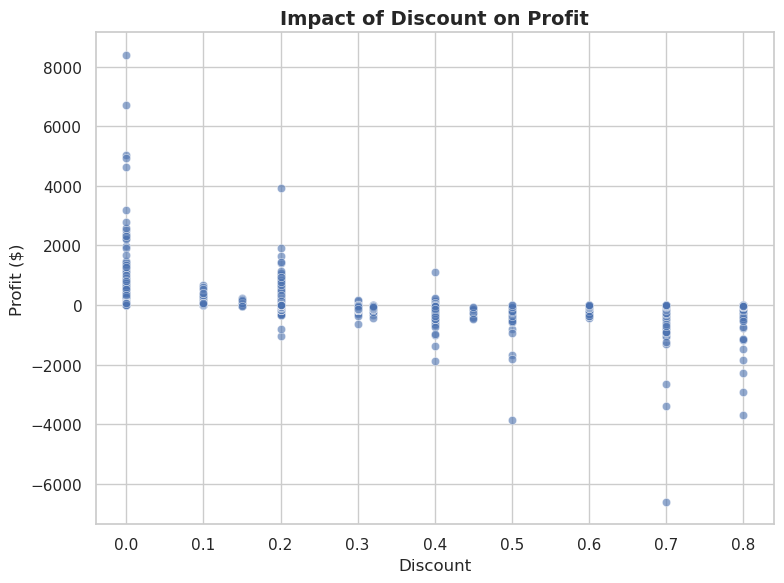

```python
plt.figure(figsize=(8,6))

sns.scatterplot(
    data=df,
    x="Discount",
    y="Profit",
    alpha=0.6
)

plt.title(
    "Impact of Discount on Profit",
    fontsize=14,
    fontweight="bold"
)

plt.xlabel("Discount")
plt.ylabel("Profit ($)")

plt.tight_layout()

plt.savefig(
    "images/discount_profit.png",
    dpi=300,
    bbox_inches="tight"
)

plt.show()
```

### Key Insight

The analysis indicates that higher discount levels are generally associated with lower profitability, with many heavily discounted transactions resulting in financial losses. This highlights the importance of balancing promotional discounts with sustainable profit margins.

## Top 10 Customers by Sales

### Objective

Identify the highest-value customers based on total sales revenue.

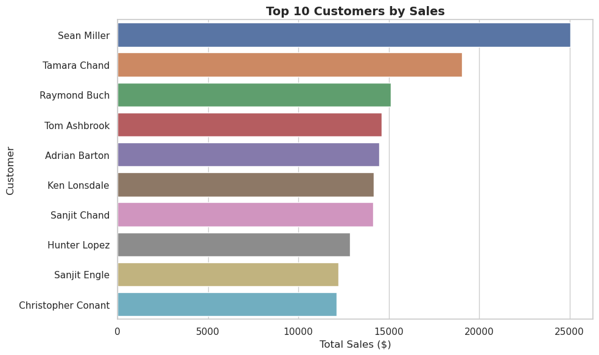

```
Customer Name
Sean Miller           25043.050
Tamara Chand          19052.218
Raymond Buch          15117.339
Tom Ashbrook          14595.620
Adrian Barton         14473.571
Ken Lonsdale          14175.229
Sanjit Chand          14142.334
Hunter Lopez          12873.298
Sanjit Engle          12209.438
Christopher Conant    12129.072
Name: Sales, dtype: float64
```

```python
top_customers = (
    df.groupby("Customer Name")["Sales"]
      .sum()
      .sort_values(ascending=False)
      .head(10)
)

plt.figure(figsize=(10,6))

sns.barplot(
    data=top_customers.reset_index(),
    x="Sales",
    y="Customer Name"
)

plt.title(
    "Top 10 Customers by Sales",
    fontsize=14,
    fontweight="bold"
)

plt.xlabel("Total Sales ($)")
plt.ylabel("Customer")

plt.tight_layout()

plt.show()

top_customers
```

## Sales by State

### Objective

Compare sales performance across states to identify high-performing and underperforming geographic markets.

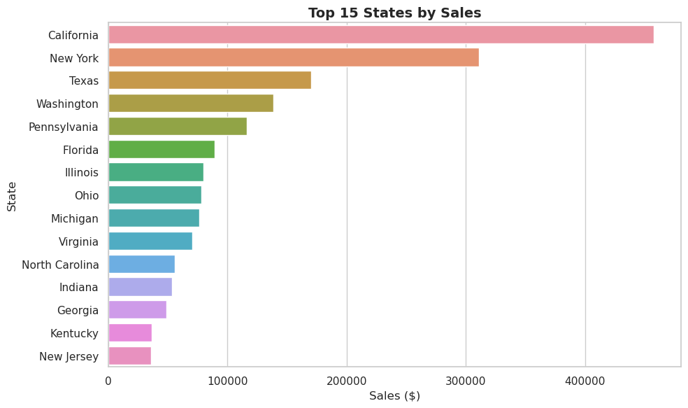

```
State
California        457687.6315
New York          310876.2710
Texas             170188.0458
Washington        138641.2700
Pennsylvania      116511.9140
Florida            89473.7080
Illinois           80166.1010
Ohio               78258.1360
Michigan           76269.6140
Virginia           70636.7200
North Carolina     55603.1640
Indiana            53555.3600
Georgia            49095.8400
Kentucky           36591.7500
New Jersey         35764.3120
Name: Sales, dtype: float64
```

```python
state_sales = (
    df.groupby("State")["Sales"]
      .sum()
      .sort_values(ascending=False)
      .head(15)
)

plt.figure(figsize=(10,6))

sns.barplot(
    data=state_sales.reset_index(),
    x="Sales",
    y="State"
)

plt.title(
    "Top 15 States by Sales",
    fontsize=14,
    fontweight="bold"
)

plt.xlabel("Sales ($)")
plt.ylabel("State")

plt.tight_layout()

plt.show()

state_sales
```

### Key Insight

California generated the highest sales (**$457,688**), followed by New York (**$310,876**) and Texas (**$170,188**). These states represent the company's strongest markets and may benefit from continued investment, while lower-performing states present opportunities for market expansion and targeted promotional activities.

## Top 15 Cities by Sales

### Objective

Identify cities that generate the highest sales revenue.

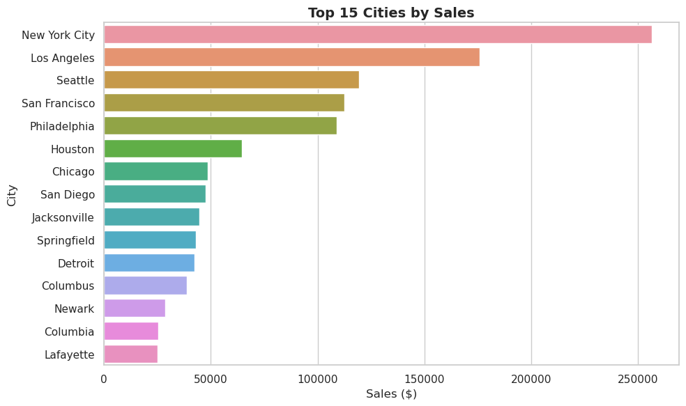

```
City
New York City    256368.1610
Los Angeles      175851.3410
Seattle          119540.7420
San Francisco    112669.0920
Philadelphia     109077.0130
Houston           64504.7604
Chicago           48539.5410
San Diego         47521.0290
Jacksonville      44713.1830
Springfield       43054.3420
Detroit           42446.9440
Columbus          38706.2430
Newark            28576.1190
Columbia          25283.3240
Lafayette         25036.2000
Name: Sales, dtype: float64
```

```python
city_sales = (
    df.groupby("City")["Sales"]
      .sum()
      .sort_values(ascending=False)
      .head(15)
)

plt.figure(figsize=(10,6))

sns.barplot(
    data=city_sales.reset_index(),
    x="Sales",
    y="City"
)

plt.title(
    "Top 15 Cities by Sales",
    fontsize=14,
    fontweight="bold"
)

plt.xlabel("Sales ($)")
plt.ylabel("City")

plt.tight_layout()

plt.show()

city_sales
```

### Key Insight

New York City generated the highest sales (**$256,368**), followed by Los Angeles and Seattle. Concentrating marketing efforts and inventory planning in these high-performing cities can further strengthen revenue growth while supporting expansion strategies in emerging markets.

# Executive Summary

This analysis examined historical retail sales data to evaluate business performance across products, customers, regions, and time. The findings provide valuable insights into revenue generation, profitability, customer purchasing behavior, and operational performance.

## Summary of Key Findings

# Business Recommendations

Based on the analysis, the following recommendations are proposed to improve business performance:

### 1. Optimize Discount Strategy

Review high-discount transactions and implement pricing strategies that balance customer acquisition with profitability.

### 2. Focus on High-Performing Products

Increase inventory availability and marketing investment for products that consistently generate strong sales and profit.

### 3. Improve Low-Profit Products

Investigate products with consistently low or negative profit margins to determine whether pricing, supplier costs, or promotional strategies should be adjusted.

### 4. Strengthen Regional Performance

Allocate additional marketing resources to high-performing regions while developing targeted strategies to improve sales in underperforming markets.

### 5. Enhance Customer Retention

Develop loyalty programs and personalized marketing campaigns for high-value customers to encourage repeat purchases and increase customer lifetime value.

### 6. Leverage Seasonal Trends

Use historical sales trends to improve demand forecasting, inventory planning, and promotional scheduling during peak business periods.

# Conclusion

This project demonstrated an end-to-end retail sales analytics workflow, beginning with data inspection and cleaning, followed by exploratory data analysis and business-focused analytics. The analysis transformed transactional sales data into actionable insights that can support strategic decision-making in areas such as sales performance, profitability, customer management, and regional planning.

The project highlights the importance of combining technical data analysis skills with business understanding to generate meaningful recommendations that create organizational value.